# Final Project/Research

Eli Hartung

### Currently, I am studying the recruitment characteristics of Arctomecon humulis; an endangered species endemic to Washington County Utah. The dwarf bear poppy grows on gypsum outcrops covered in cryptobiotic crusts. I have collected data on roughly 200 seedlings from three populations at the square foot plot and emergence point levels.

The plots below help illustrate some of the findings at the plot level.

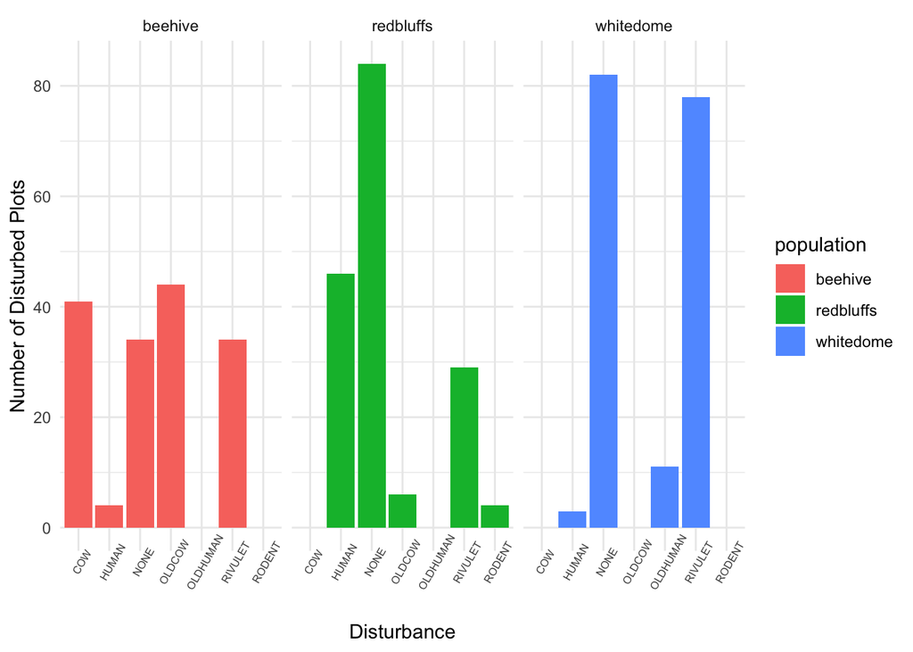

The disturbance regimes of each population and the presence of disturbance in each of these sample plots varies as well. These differences in disturbance likely play a role in the cover characteristics of these plots.

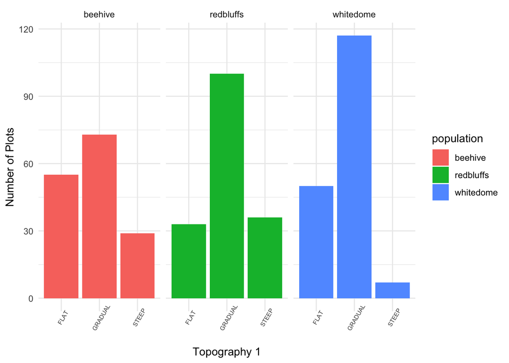

In this plot, flat refers to only a few degrees of slope along the plot, gradual is anywhere between about 10º and 45º, and steep refers to plots on slopes greater than 45º. The plants we found were most often found in gradually sloping plots.

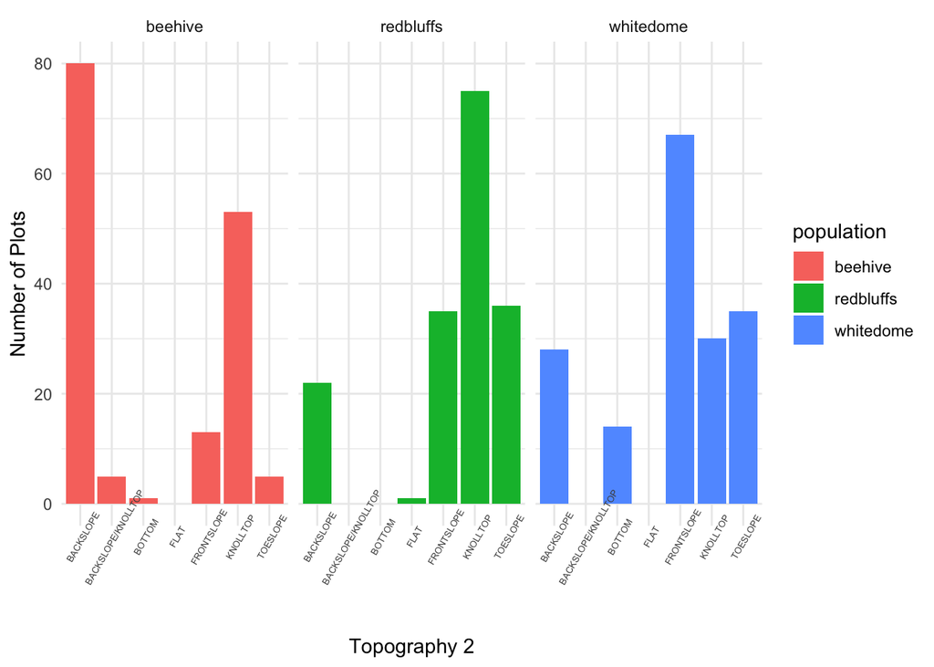

In this plot, frontslopes refer to either north or east facing slopes while backslopes refer to either south or west facing slopes. Plants were most often found in backloping plots at beehive while plants were most often found on knolltops and frontslopes at redbluffs and whitedome, respectively.

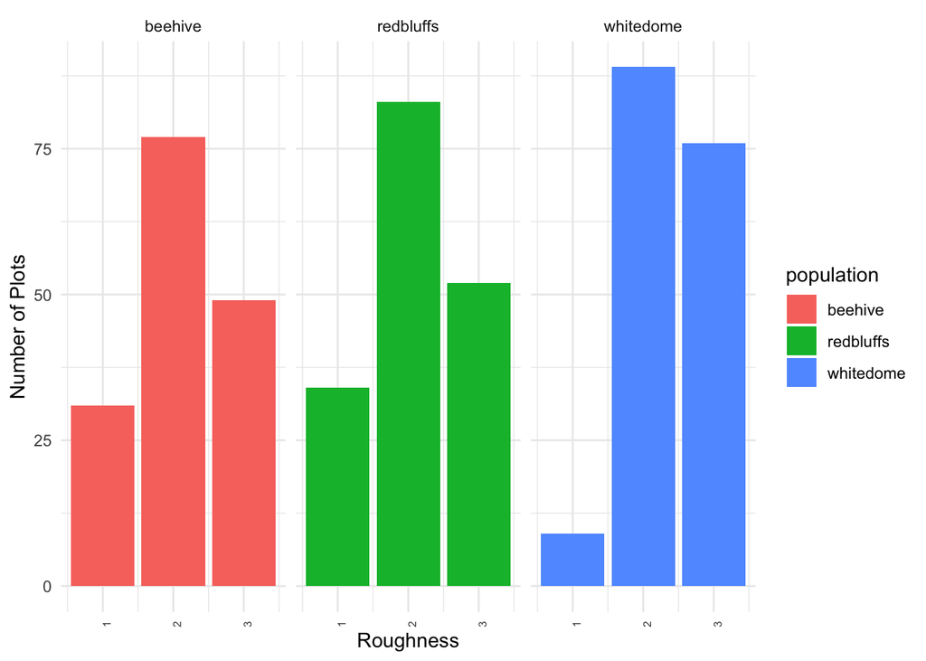

The cover of these plots varied and were different between populations.

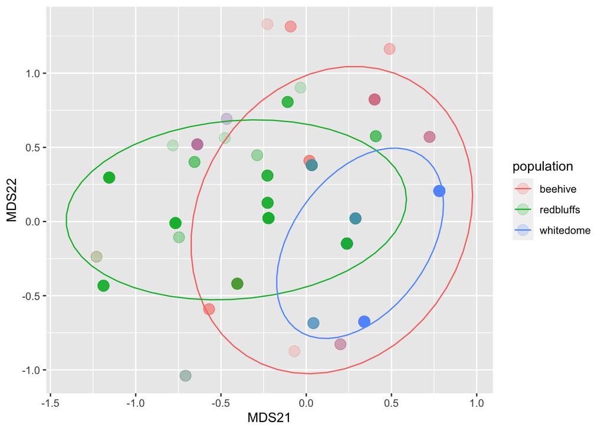

```
##
## Call:
## adonis(formula = cover_matrix1 ~ cover1$population)
##
## Permutation: free
## Number of permutations: 999
##
## Terms added sequentially (first to last)
##
##                    Df SumsOfSqs MeanSqs F.Model      R2 Pr(>F)
## cover1$population   2    14.660  7.3300  79.806 0.24308  0.001 ***
## Residuals         497    45.648  0.0918         0.75692
## Total             499    60.308                 1.00000
## ---
## Signif. codes:  0 '***' 0.001 '**' 0.01 '*' 0.05 '.' 0.1 ' ' 1
```

Significance of Cryptobiotic crust cover as a function of population.

```r
crypto_c_mod <- aov(data=cover1,
                    formula = crypto_c ~ population)
summary(crypto_c_mod)
```

```
##              Df Sum Sq Mean Sq F value   Pr(>F)
## population    2   97.5   48.75    31.1 1.89e-13 ***
## Residuals   497  779.1    1.57
## ---
## Signif. codes:  0 '***' 0.001 '**' 0.01 '*' 0.05 '.' 0.1 ' ' 1
```

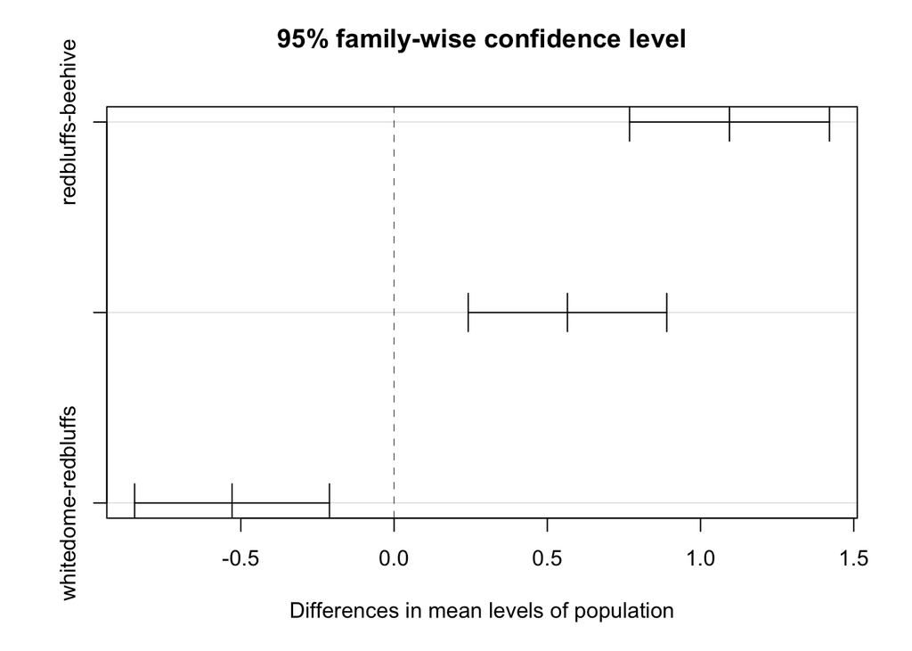

Significance of small gravel (less than a cm in diameter) cover as a function of population.

```r
sm_gr_c_mod <- aov(data=cover1,
                   formula = sm_gr_c ~ population)
summary(sm_gr_c_mod)
```

```
##              Df Sum Sq Mean Sq F value Pr(>F)
## population    2   73.9   36.96   46.65 <2e-16 ***
## Residuals   497  393.8    0.79
## ---
## Signif. codes:  0 '***' 0.001 '**' 0.01 '*' 0.05 '.' 0.1 ' ' 1
```

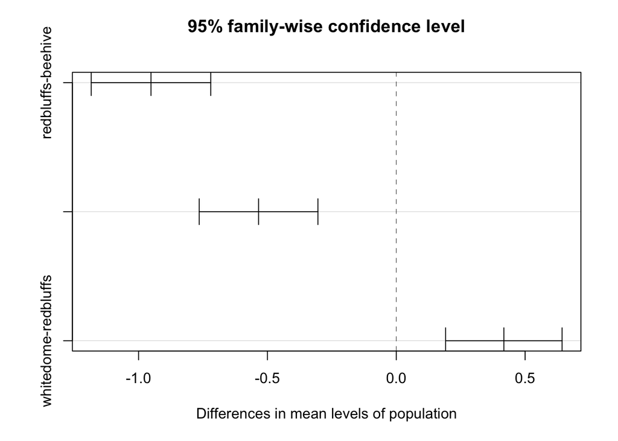

Significance of large gravel (greater than a cm in diameter) cover as a function of population.

```r
lg_gr_c_mod <- aov(data=cover1,
                   formula = lg_gr_c ~ population)
summary(lg_gr_c_mod)
```

```
##              Df Sum Sq Mean Sq F value Pr(>F)
## population    2   76.7   38.37   58.17 <2e-16 ***
## Residuals   497  327.8    0.66
## ---
## Signif. codes:  0 '***' 0.001 '**' 0.01 '*' 0.05 '.' 0.1 ' ' 1
```

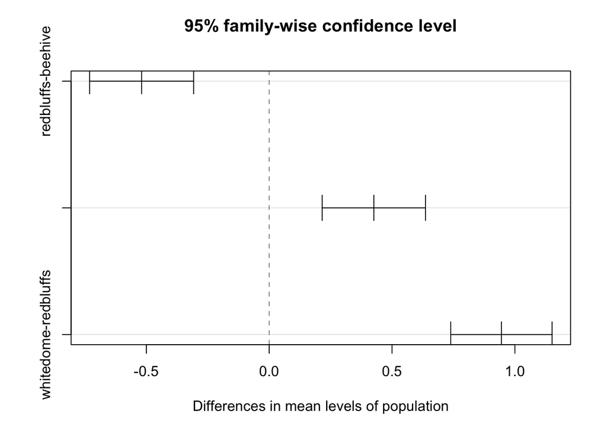

Significance of exposed gypsum cover as a function of population.

```r
gyp_c_mod <- aov(data=cover1,
                 formula = gyp_c ~ population)
summary(gyp_c_mod)
```

```
##              Df Sum Sq Mean Sq F value   Pr(>F)
## population    2    5.9  2.9506   12.82 3.71e-06 ***
## Residuals   497  114.3  0.2301
## ---
## Signif. codes:  0 '***' 0.001 '**' 0.01 '*' 0.05 '.' 0.1 ' ' 1
```

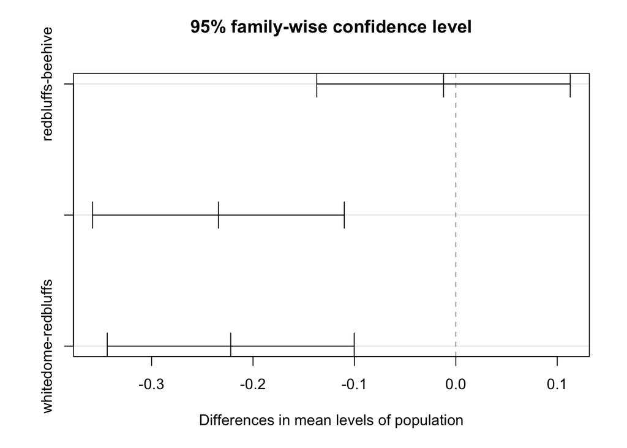

Significance of neighboring plant cover as a function of population.

```r
plant_c_mod <- aov(data=cover1,
                 formula = plant_c ~ population)
summary(plant_c_mod)
```

```
##              Df Sum Sq Mean Sq F value  Pr(>F)
## population    2   1.24  0.6221   5.327 0.00514 **
## Residuals   497  58.04  0.1168
## ---
## Signif. codes:  0 '***' 0.001 '**' 0.01 '*' 0.05 '.' 0.1 ' ' 1
```

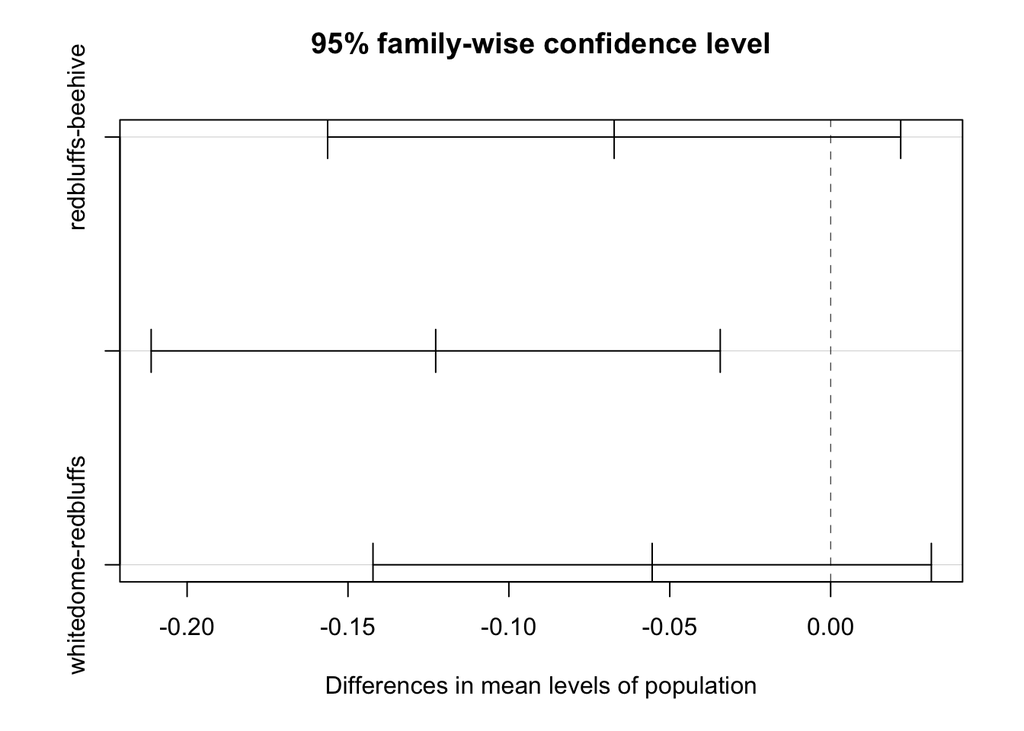

Significance of bare soil cover as a function of population.

```r
bare_c_mod <- aov(data=cover1,
                 formula = bare_c ~ population)
summary(bare_c_mod)
```

```
##              Df Sum Sq Mean Sq F value Pr(>F)
## population    2  151.2   75.63   331.1 <2e-16 ***
## Residuals   497  113.5    0.23
## ---
## Signif. codes:  0 '***' 0.001 '**' 0.01 '*' 0.05 '.' 0.1 ' ' 1
```

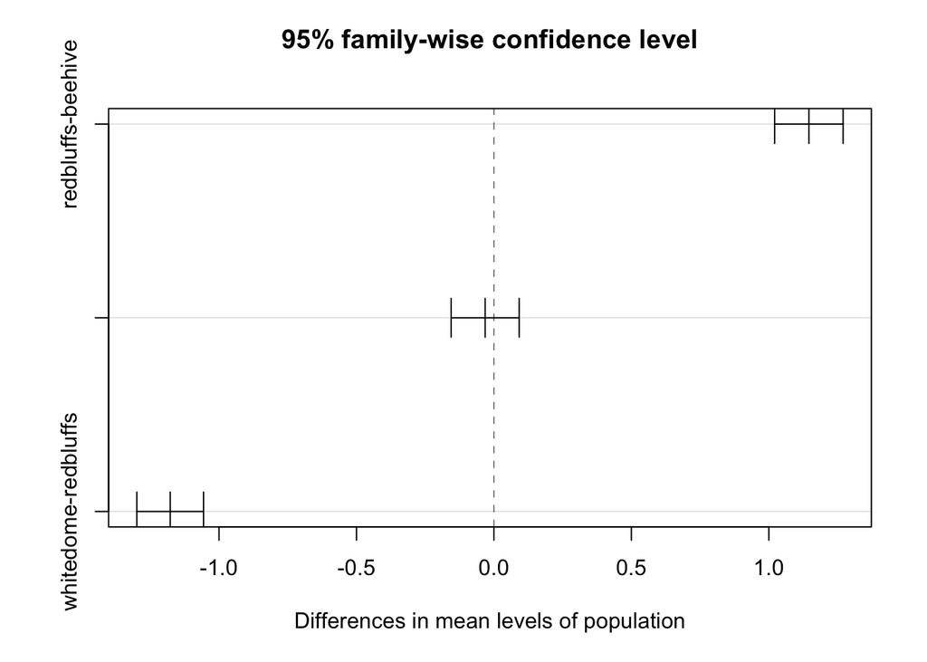

#### The percent cover of each cover type was significanyly different across populations and shows diffences in habitable plot composition between sites.

#### At the emergence point level, plants recruited into and grew from different materials within and between populations.

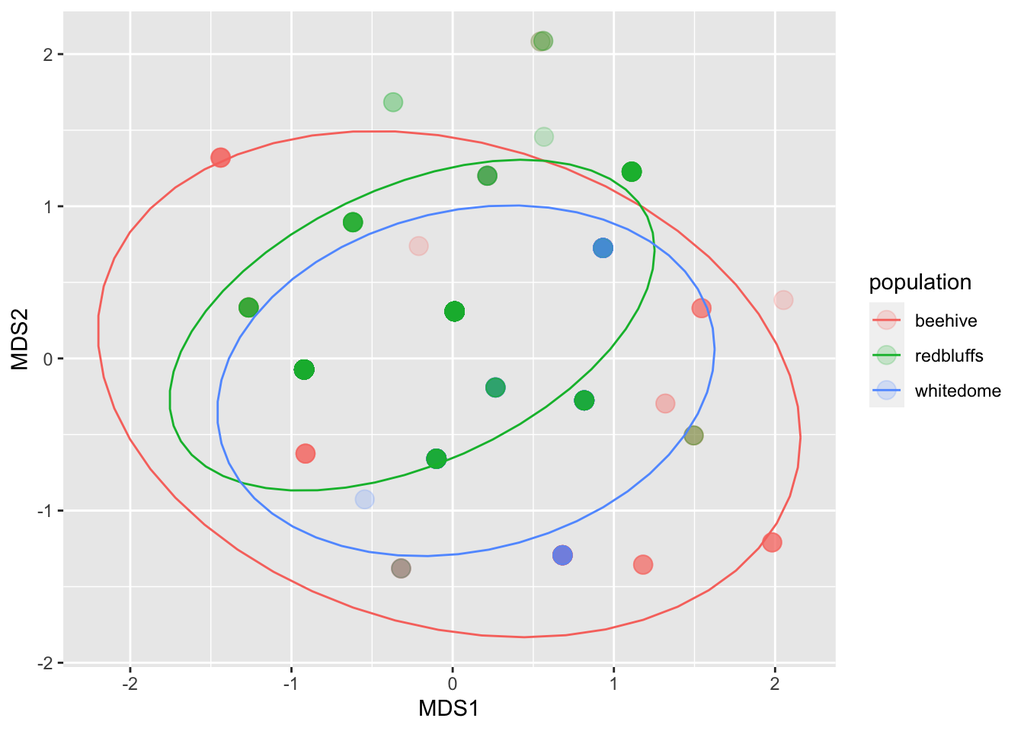

Using the models shown below, we can see the predicted values for emergence substrates across populations.

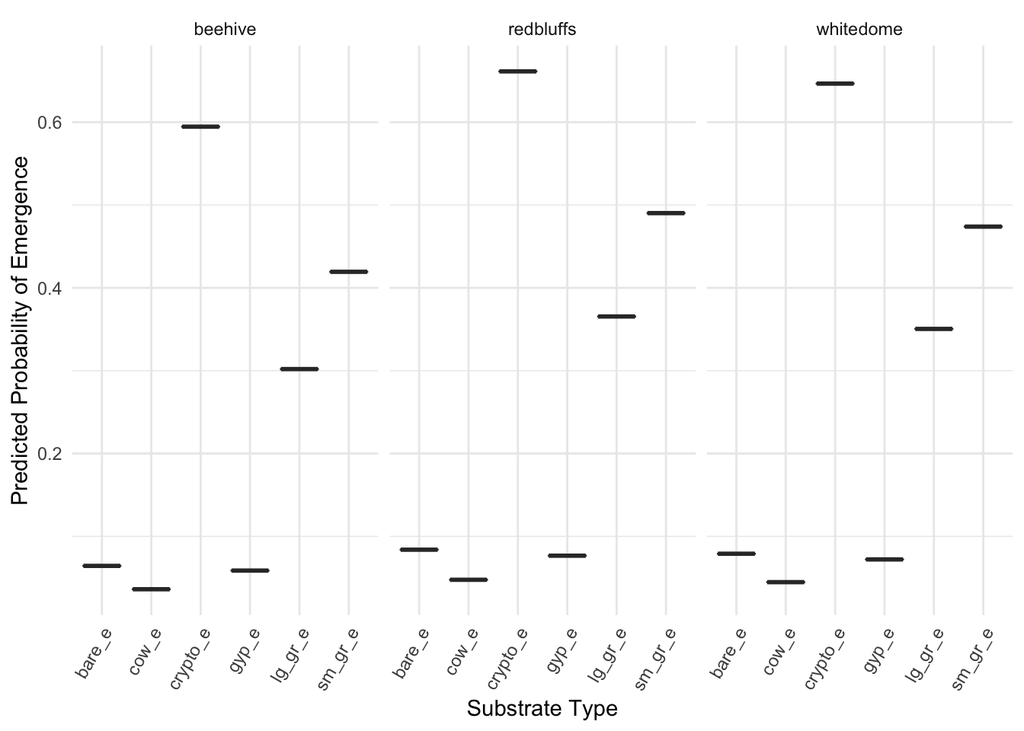

```r
long <- emergence1 %>%
  pivot_longer(ends_with("_e"),names_to="Substrate",values_to="Emergence")
mod_logistic2 <- glm(data=long,
                     formula = Emergence ~ Substrate + population,
                     family="binomial")



add_predictions(long,mod_logistic2,type="response") %>%
  ggplot(aes(x=Substrate,y=pred)) + geom_boxplot() + facet_wrap(~population) +
  theme_minimal() +
  theme(axis.text.x = element_text(angle=60,hjust=1))  +
  labs(x= "Substrate Type", y= "Predicted Probability of Emergence")
```

bare_e refers to emergence from bare soil, cow_e refers to emergence from a cow track, crypto_e refers to emergence from cryptopbiotic crust, gyp_e refers to emergence from exposed gypsum, lg_gr_e refers to emergence from large gravel, and sm_gr_e refers to emergence from small gravel. Even though the populations for the Dwarf Bear Poppy vary widely at the plot level, there are many similarities among them for plant emergence. Across all three populations, there seems to be a much higher probability for emergence from cryptobiotic crust and gravel while emergence from bare soil, cow tracks, and gypsum seem to be much less likely.